# Week 2 recap - Data, functions and colors

9/17/2020

```r
library(tidycensus)
library(tidyverse)
library(ggplot2)
library(lemon)
knit_print.data.frame <- lemon_print


# list of themes can be found here https://www.datadreaming.org/post/r-markdown-theme-gallery/
```

## 1.Getting the census data

tidycensus is an R package that allows users to interface with the US Census Bureau’s decennial Census and American Community Survey and return data frames. There are three ways of getting data from tidycensus: get_pums, get_acs and get_decennial().

### 1.1. Public Use Microdata Series

PUMS contains data about individuals and households and is collected through American Community Survey - a demographics survey conducted every year on a sample of about 2 million households. The estimates for the entire population are calculated based on the collected sample, which is the reason you get two values for a single variable - estimate and moe (margin of error). You can select a one-year survey (acs1) or a five-year survey (acs5).

If you need international individual/household data, you can use https://ipums.org/.

How to get PUMS data?

```r
# explore PUMS variables by passing the function pums_variables.

pums_explore_1 <- pums_variables

# Calling pums_variables on its own is not too useful, we get too many variables.
# Let's select only one-year, person-level data for the year 2017.
# The function filter() allows us to select rows based on some condition.

pums_explore_2 <-pums_variables %>%
  filter(level == "person", year == 2017, survey == "acs1")

# you can narrow the selection further by using distinct() to get unique variables.

pums_explore_3 <-pums_variables %>%
  filter(level == "person", year == 2017, survey == "acs1") %>%
  distinct(year, survey, var_code, var_label, data_type, level)

# the code above helps us explore the (names of) variables in the dataset. To get the actual data, use get_pums.

data_pums <- get_pums(c("AGEP", "MAR", "MIL"), state="WY", year=2018, survey = "acs5")

# the dataframe data_pums has several columns we don't need (such as serial number, state code, etc.). To select the specific columns, we use function select().

data_pums_cleaned <- data_pums %>% select(AGEP,MAR,MIL)
```

### 1.2. American Community Survey (acs)

ACS tabulates individual-level data to a geographic region. Geography available at https://walker-data.com/tidycensus/articles/basic-usage.html.

```r
# explore the variables in acs. load_variables is analogous to pums_variables - use it to explore variables.

acs_explore <- load_variables(2017, "acs5")


# To get the data, use get_data. You can specify the desired variables directly in the function, for example get_acs(..., c("B01002_001E", "B01003_001E"), ...), or create a list beforhand. If you use more than 2-3 variables, it's good practice to make a list (name it vars or something similar), just so your code is easier to read.

vars = c(age = "B01002_001E", income ="B06011_001E", total_trips = "B08501_001E", trips_by_car = "B08501_009E")

data_acs <- get_acs(geography = "county", variables = vars,
                    year = 2018, survey = "acs5", output = "wide")

data_acs <- data_acs %>% select(GEOID, NAME, age,income,total_trips,trips_by_car)
```

For tutorials on ggplot go to https://vis-2129-f2020.github.io/tutorials/

### 1.3. Decennial (10-year) census

Census is the most accurate individual-level survey conducted every 10 years.

```r
#explore the dataset

decennial_explore <- load_variables(2010, "sf1")

#select variables

data_decennial <- get_decennial(geography = "block", variables = c(vacancy = "H005001", Hisp_pop ="H007001"), year = 2010, state = "WY", county = "Teton County", output = "wide") %>%  filter(vacancy>0)
```

## 2. Useful functions in R (so far)

### nrow(), ncol(), dim()

These functions calculate the number of rows (nrow), number of columns (ncol), or both (dim) in the data frame. The functions are very useful for data exploration and data cleaning.

```r
print(c(nrow(data_acs), ncol(data_acs)))
```

```
## [1] 3220    6
```

### head()

The head(data, n) function takes a data frame (fancy name for a table) and an argument “n” and returns the first n rows of a data frame or matrix. By default it returns first 6 rows.

```r
head(data_acs)
```

| GEOID | NAME | age | income | total_trips | trips_by_car |
| --- | --- | --- | --- | --- | --- |
| 28151 | Washington County, Mississippi | 36.9 | 19069 | 17138 | 14888 |
| 28111 | Perry County, Mississippi | 40.9 | 19724 | 3056 | 2527 |
| 28019 | Choctaw County, Mississippi | 44.0 | 18967 | 2104 | 1737 |
| 28057 | Itawamba County, Mississippi | 40.0 | 21698 | 6602 | 5116 |
| 28015 | Carroll County, Mississippi | 47.0 | 22091 | 1305 | 1143 |
| 28043 | Grenada County, Mississippi | 39.8 | 21741 | 10104 | 8888 |

```r
head(data_acs, 2)
```

| GEOID | NAME | age | income | total_trips | trips_by_car |
| --- | --- | --- | --- | --- | --- |
| 28151 | Washington County, Mississippi | 36.9 | 19069 | 17138 | 14888 |
| 28111 | Perry County, Mississippi | 40.9 | 19724 | 3056 | 2527 |

### if-else

If-else statements are used for testing if a condition is true. It’s form is:  
*if (condition) {do something} else {do something else}*

```r
x <- 42

if (x>2)
  {print("x is larger than two")} else
  {print("x is not larger than two")}
```

```
## [1] "x is larger than two"
```

```r
# we can add multiple conditions with else if

x <- 2

if (x>2)
  {print("x is larger than two")} else if (x == 2)
    {print("x is two")} else
      {print("x is smaller than two")}
```

```
## [1] "x is two"
```

### case_when

This function performs if-else statements on each element in a vector (list, matrix or data frame). Usage:  
case_when(logical_statement ~ replacement). The left hand side determines which values in the data frame match the condition. The right hand side provides the replacement value.

```r
# x is a list of numbers from 1 to 20. Let's replace even numbers with a string "even number". Symbol %% calculates the remainder.

x <- 1:20

case_when(
  x %% 2 == 0 ~ "even number",
  x %% 2 == 1 ~ as.character(x)
)
```

```
##  [1] "1"           "even number" "3"           "even number" "5"
##  [6] "even number" "7"           "even number" "9"           "even number"
## [11] "11"          "even number" "13"          "even number" "15"
## [16] "even number" "17"          "even number" "19"          "even number"
```

Function case_when is very useful in combination with mutate() function presented below.

### select()

Select function is used to select variables (columns).The function requires a data frame and a list of columns, select(data, column_name1, column_name2…)

```r
# you can specify desired columns directly in the function...

new_data <- select(data_acs, NAME, income)
head(new_data,2)
```

| NAME | income |
| --- | --- |
| Washington County, Mississippi | 19069 |
| Perry County, Mississippi | 19724 |

```r
# ... or in a separate variable

cols <- c("NAME", "age", "income", "total_trips")
new_data <- select(data_acs, cols)
head(new_data,2)
```

| NAME | age | income | total_trips |
| --- | --- | --- | --- |
| Washington County, Mississippi | 36.9 | 19069 | 17138 |
| Perry County, Mississippi | 40.9 | 19724 | 3056 |

```r
# finally, you can specify the range of columns you want to select. Column1:Column4 selects all columns between positions 1 and 4 (including those two).

new_data <- select(data_acs, NAME:total_trips)
head(new_data,2)
```

| NAME | age | income | total_trips |
| --- | --- | --- | --- |
| Washington County, Mississippi | 36.9 | 19069 | 17138 |
| Perry County, Mississippi | 40.9 | 19724 | 3056 |

### filter()

The filter() function is used to subset a data frame (to select rows) by specifying conditions. To be retained, the row must produce a value of TRUE for all conditions. Rows that contain NA values are dropped.

```r
nrow(data_acs)
```

```
## [1] 3220
```

```r
# select rows where median age is above 40.
new_data <- filter(data_acs, age > 40)
nrow(new_data)
```

```
## [1] 1959
```

```r
# we can also specify multiple conditions.
# For example, retain rows where age is above 40 and median income > $40k.

new_data <- filter(data_acs, age > 40 & income > 40000)
nrow(new_data)
```

```
## [1] 32
```

### mutate() and transmute()

mutate() adds new variables and preserves existing ones; transmute() adds new variables and drops existing ones. New variables overwrite existing variables of the same name. The first function takes the form of  
*mutate(data, new_variable = f(existing_variable))*

```r
# add a column with percents of trips taken by a car.

new_data <- mutate(data_acs, percent_trips_by_car = trips_by_car/total_trips)
head(new_data,2)
```

| GEOID | NAME | age | income | total_trips | trips_by_car | percent_trips_by_car |
| --- | --- | --- | --- | --- | --- | --- |
| 28151 | Washington County, Mississippi | 36.9 | 19069 | 17138 | 14888 | 0.8687128 |
| 28111 | Perry County, Mississippi | 40.9 | 19724 | 3056 | 2527 | 0.8268979 |

```r
# return only one column with percents of trips taken by a car

new_data <- transmute(data_acs, percent_trips_by_car = trips_by_car/total_trips)
head(new_data,2)
```

| percent_trips_by_car |
| --- |
| 0.8687128 |
| 0.8268979 |

The combination case_when() and mutate() is great for converting continuous variables into discrete. Let’s add a categorical variable income_cat that tells us if the median income in a county is low or high.

```r
plot_data <- data_acs %>% mutate(income_cat = case_when(income <= 20000 ~ "low",
                                                       income > 20000 ~ "high"))
head(plot_data)
```

| GEOID | NAME | age | income | total_trips | trips_by_car | income_cat |
| --- | --- | --- | --- | --- | --- | --- |
| 28151 | Washington County, Mississippi | 36.9 | 19069 | 17138 | 14888 | low |
| 28111 | Perry County, Mississippi | 40.9 | 19724 | 3056 | 2527 | low |
| 28019 | Choctaw County, Mississippi | 44.0 | 18967 | 2104 | 1737 | low |
| 28057 | Itawamba County, Mississippi | 40.0 | 21698 | 6602 | 5116 | high |
| 28015 | Carroll County, Mississippi | 47.0 | 22091 | 1305 | 1143 | high |
| 28043 | Grenada County, Mississippi | 39.8 | 21741 | 10104 | 8888 | high |

### Pipe operator %>%

This operator will forward a value, or the result of an expression, into the next function call/expression. Essentially, take a function on the right and pass it to the data on the left. For example, a function to display data can be written as:

```r
head(data_acs,2)
```

| GEOID | NAME | age | income | total_trips | trips_by_car |
| --- | --- | --- | --- | --- | --- |
| 28151 | Washington County, Mississippi | 36.9 | 19069 | 17138 | 14888 |
| 28111 | Perry County, Mississippi | 40.9 | 19724 | 3056 | 2527 |

Or we can use pipe operator and “chain” the functions:

```r
data_acs %>% head(2)
```

| GEOID | NAME | age | income | total_trips | trips_by_car |
| --- | --- | --- | --- | --- | --- |
| 28151 | Washington County, Mississippi | 36.9 | 19069 | 17138 | 14888 |
| 28111 | Perry County, Mississippi | 40.9 | 19724 | 3056 | 2527 |

If you are not using %>% then data needs to be inside the function - head(data). If you are using it, push the data to the left - data %>% head(). The methods are equivalent.

```r
new_data1 <- filter(data_acs, age>40)
new_data2 <- data_acs %>% filter(age>40)

# let's check if new_data1 and new_data2 are the same. We can use all.equal(a,b) function to test that.

if (all.equal(new_data1, new_data2))
  {print("Two data frames are the same")} else
  {print("They are different")}
```

```
## [1] "Two data frames are the same"
```

One advantage of using %>% is when you need to chain multiple functions. The code is easier to write and read.

```r
# here we select the column "age" from data_acs, filter all ages above 40, and add another column called age_doubled with ages multiplied by 2. Although there are 3 functions, with %>% it is easy to understand the code.

new_data <- data_acs %>% select(NAME, age) %>% filter(age>40) %>% mutate(age_doubled = age*2)
head(new_data, 2)
```

| NAME | age | age_doubled |
| --- | --- | --- |
| Perry County, Mississippi | 40.9 | 81.8 |
| Choctaw County, Mississippi | 44.0 | 88.0 |

```r
# same thing, but not really legible.
new_data <- mutate(filter(select(data_acs,NAME, age), age>40 ), age_doubled = age*2)
head(new_data, 2)
```

| NAME | age | age_doubled |
| --- | --- | --- |
| Perry County, Mississippi | 40.9 | 81.8 |
| Choctaw County, Mississippi | 44.0 | 88.0 |

## 3. Colors in ggplot

In this section, we will see how to set and change colors in ggplot. We will see the difference between the parameter *color* in the aes() function (aes(data, x=var1, y=var2, color = var3)) and *color* used to set the actual color of the plot. Let’s first get some data to visualize.

```r
plot_data <- data_acs %>% mutate(pct_by_car = trips_by_car/total_trips, income_cat = case_when(income <= 20000 ~ "low", income > 20000 ~ "high"))

plot_data <- na.omit(plot_data)
head(plot_data, 2)
```

| GEOID | NAME | age | income | total_trips | trips_by_car | pct_by_car | income_cat |
| --- | --- | --- | --- | --- | --- | --- | --- |
| 28151 | Washington County, Mississippi | 36.9 | 19069 | 17138 | 14888 | 0.8687128 | low |
| 28111 | Perry County, Mississippi | 40.9 | 19724 | 3056 | 2527 | 0.8268979 | low |

### 3.1. Scatter plot

In ggplot, we can pass aesthetic parameter (aes()) to define how variables in the data are mapped to visual properties (aesthetics) of geoms. In scatter plot, we usually use x and y parameter (aes(x=var1, y=var2)) to visualize the relationship between x and y. However, we can pass additional parameter “color” to visualize a third variable on our chart. Here, we will focus on that color parameter - aes(…, color = variable, …). There are three options, color = None, color = discrete variable and color = continuous variable.

#### No color

Let’s plot a simple scatter plot. By passing only x and y parameters - aes(x = something, y = something else), we share two pieces of information - position on x and y axis.

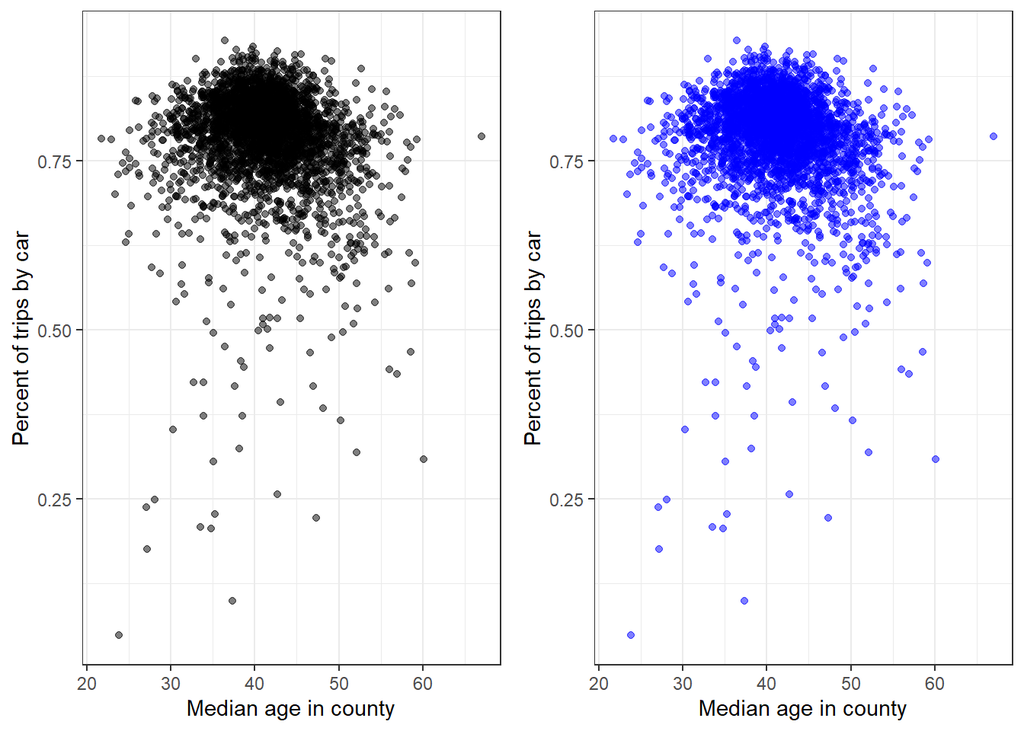

```r
# with aes(x,y) we only show the position of the dots on the plot.

plot1 <- ggplot(plot_data,
       aes(x = age,
           y = pct_by_car)) +
  geom_point(alpha = 0.5) +
  scale_x_continuous(name = "Median age in county") +
  scale_y_continuous(name = "Percent of trips by car") +
  theme_bw()

# To change colors of the dots, we can simply use geom_point(color = "some color").

plot2 <- ggplot(plot_data,
       aes(x = age,
           y = pct_by_car)) +
  geom_point(alpha = 0.5, color = "blue") +
  scale_x_continuous(name = "Median age in county") +
  scale_y_continuous(name = "Percent of trips by car") +
  theme_bw()

library(gridExtra)
grid.arrange(plot1, plot2, ncol=2)
```

#### Color represents categorical variable

By specifying additional parameters, such as color in aes(x,y,color) we can add information to the chart. If we pass a categorical variable to *color*, then the number of colors on the chart will be equal to the number of categories in the variable.

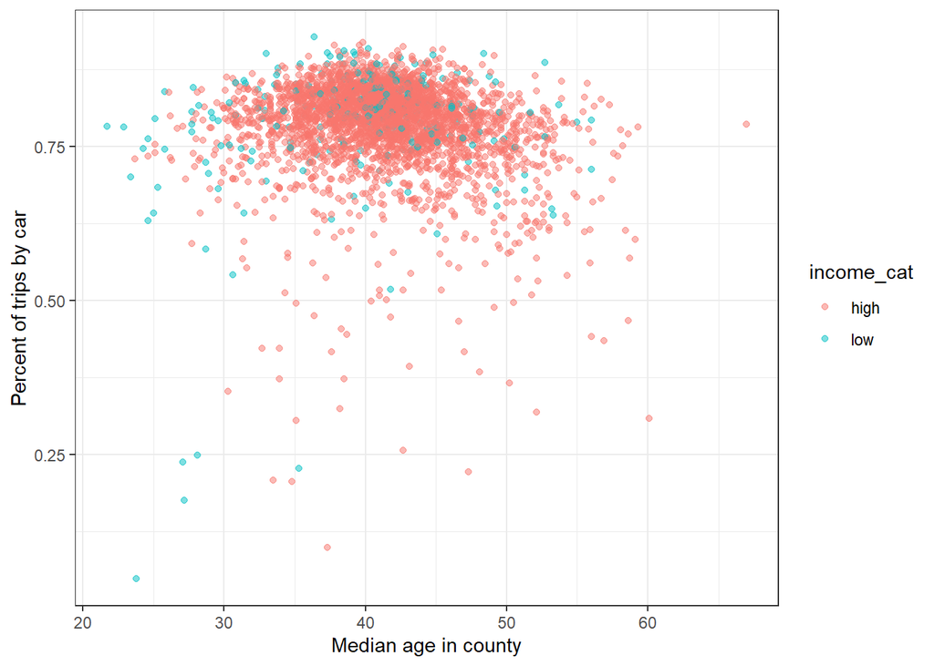

```r
# if color represents a categorical variable - number of colors are equal to the number of categories
ggplot(plot_data,
       aes(x = age,
           y = pct_by_car,
           color = income_cat)) +
geom_point(alpha = 0.5) +
  scale_x_continuous(name = "Median age in county") +
  scale_y_continuous(name = "Percent of trips by car") +
  theme_bw()
```

Colors of the dots can be changed by using scale_color_manual. In general, scale_ is used to edit parameters in aes().

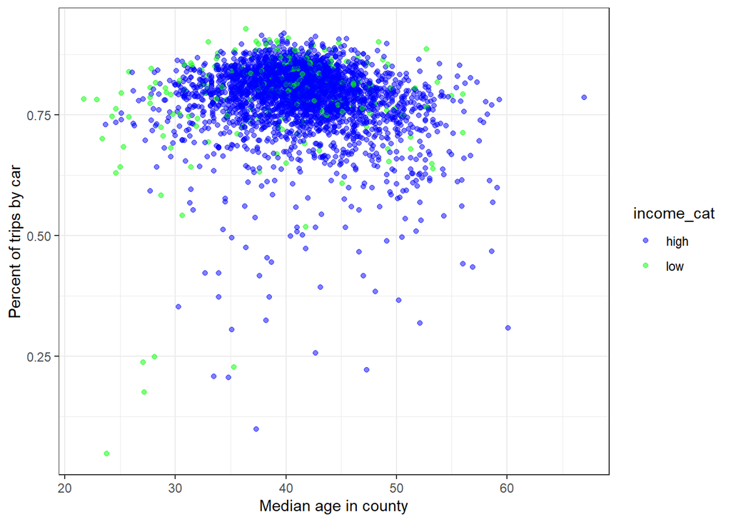

```r
ggplot(plot_data,
       aes(x = age,
           y = pct_by_car,
           color = income_cat)) +
geom_point(alpha = 0.5) +
  scale_x_continuous(name = "Median age in county") +
  scale_y_continuous(name = "Percent of trips by car") +
  scale_color_manual(values = c("blue", "green")) +
  theme_bw()
```

If you don’t want to set the colors manually, you can use pre-made palettes. This is helpful when you have large number of categories. The most commonly used color scales include:

- Viridis color scales [must import viridis package]. Function: scale_color_viridis()
- Colorbrewer palettes [RColorBrewer package]. Function: scale_color_brewer()
- Grey color palettes [ggplot2 package]. Function: scale_color_brewer()
- Scientific journal color palettes [ggsci package]. Function: scale_color_npg()
- Wes Anderson color palettes [wesanderson package]. Function: wes_palette()

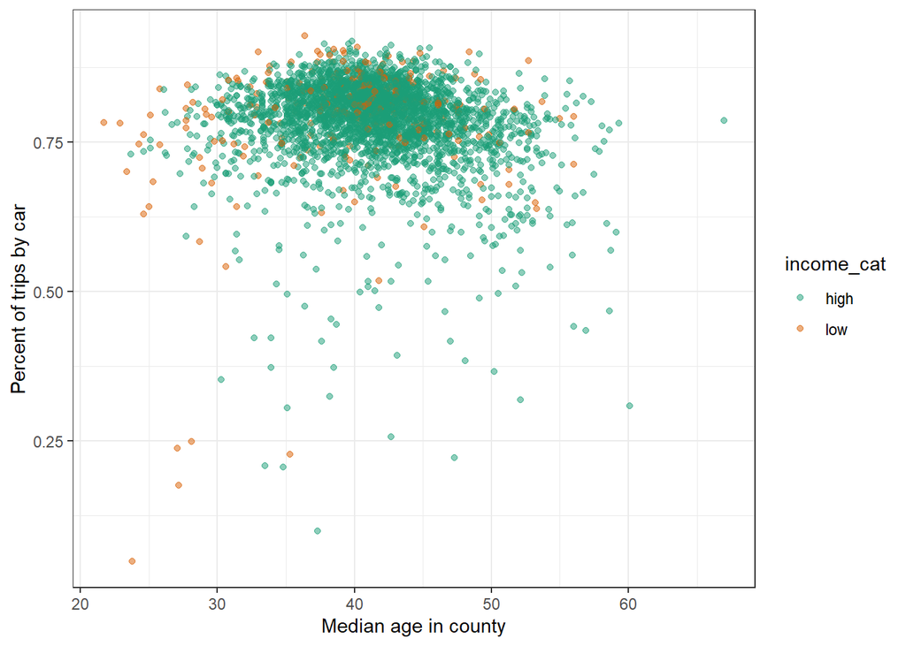

```r
library(RColorBrewer)

ggplot(plot_data,
       aes(x = age,
           y = pct_by_car,
           color = income_cat)) +
geom_point(alpha = 0.5) +
  scale_x_continuous(name = "Median age in county") +
  scale_y_continuous(name = "Percent of trips by car") +
  scale_color_brewer(palette = "Dark2") +
  theme_bw()
```

#### Color represents continuous variable

If a continuous variable is passed to parameter *color*, the simplest plot will have the dots of same color, but different gradient.

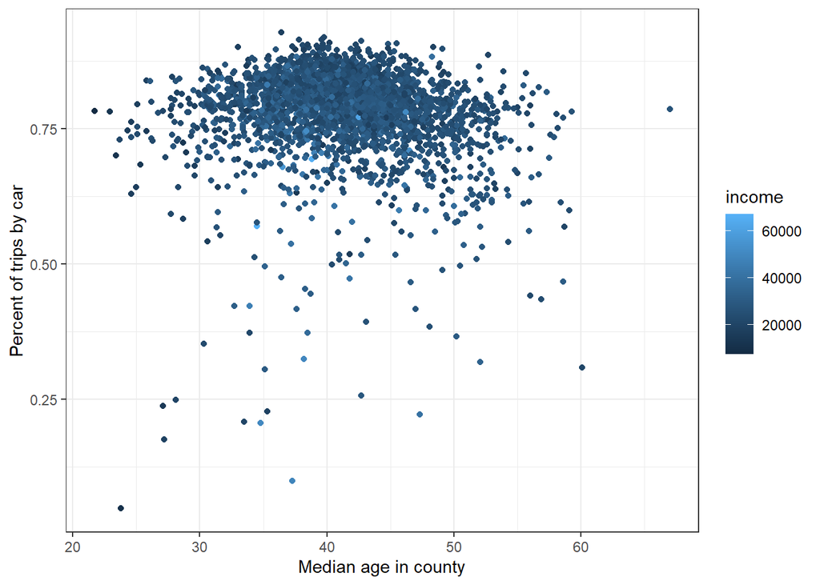

```r
# color is a continuous value presented by shades of the same color
ggplot(plot_data,
       aes(x = age,
           y = pct_by_car,
           color = income)) +
geom_point() +
  scale_x_continuous(name = "Median age in county") +
  scale_y_continuous(name = "Percent of trips by car") +
  theme_bw()
```

There are multiple ways to change color. We will cover three:

- scale_color_gradient()
- scale_color_gradientn()
- palettes

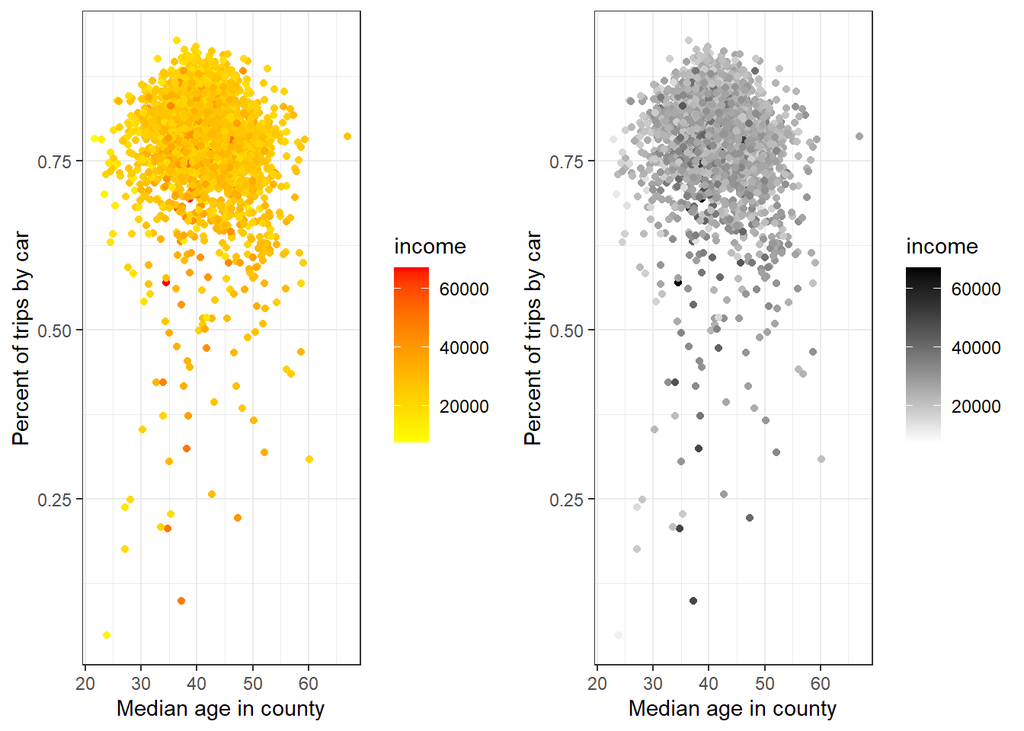

```r
# scale_color_gradient() lets us choose two boundary colors

pl1 <- ggplot(plot_data,
       aes(x = age,
           y = pct_by_car,
           color = income)) +
geom_point() +
  scale_x_continuous(name = "Median age in county") +
  scale_y_continuous(name = "Percent of trips by car") +
  scale_color_gradient(low = "yellow", high = "red") +
  theme_bw()

pl2 <- ggplot(plot_data,
       aes(x = age,
           y = pct_by_car,
           color = income)) +
geom_point() +
  scale_x_continuous(name = "Median age in county") +
  scale_y_continuous(name = "Percent of trips by car") +
  scale_color_gradient(low = "white", high = "black") +
  theme_bw()


grid.arrange(pl1, pl2, ncol=2)
```

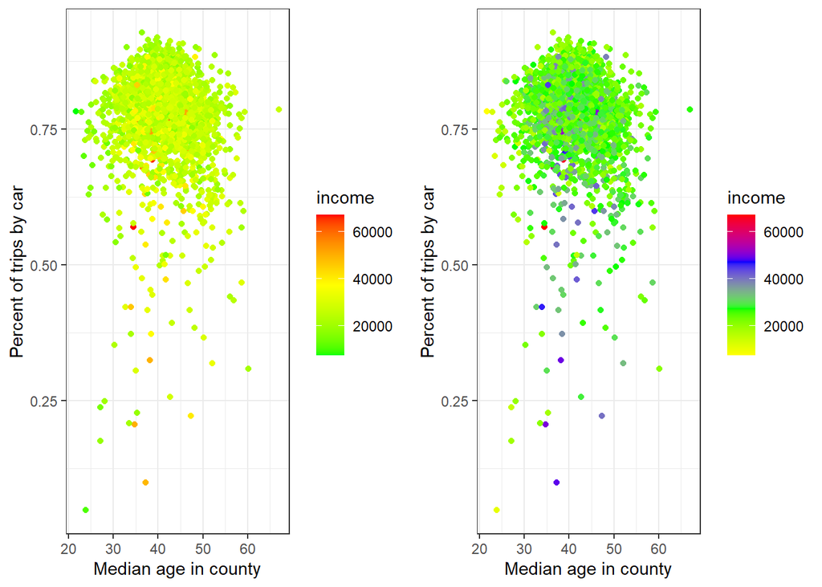

```r
# scale_color_gradientn() lets us choose however many colors we want


pl1 <- ggplot(plot_data,
       aes(x = age,
           y = pct_by_car,
           color = income)) +
geom_point() +
  scale_x_continuous(name = "Median age in county") +
  scale_y_continuous(name = "Percent of trips by car") +
  scale_color_gradientn(colors = c("green", "yellow", "red")) +
  theme_bw()

pl2 <- ggplot(plot_data,
       aes(x = age,
           y = pct_by_car,
           color = income)) +
geom_point() +
  scale_x_continuous(name = "Median age in county") +
  scale_y_continuous(name = "Percent of trips by car") +
  scale_color_gradientn(colors = c("yellow", "green", "blue", "red" )) +
  theme_bw()

grid.arrange(pl1, pl2, ncol=2)
```

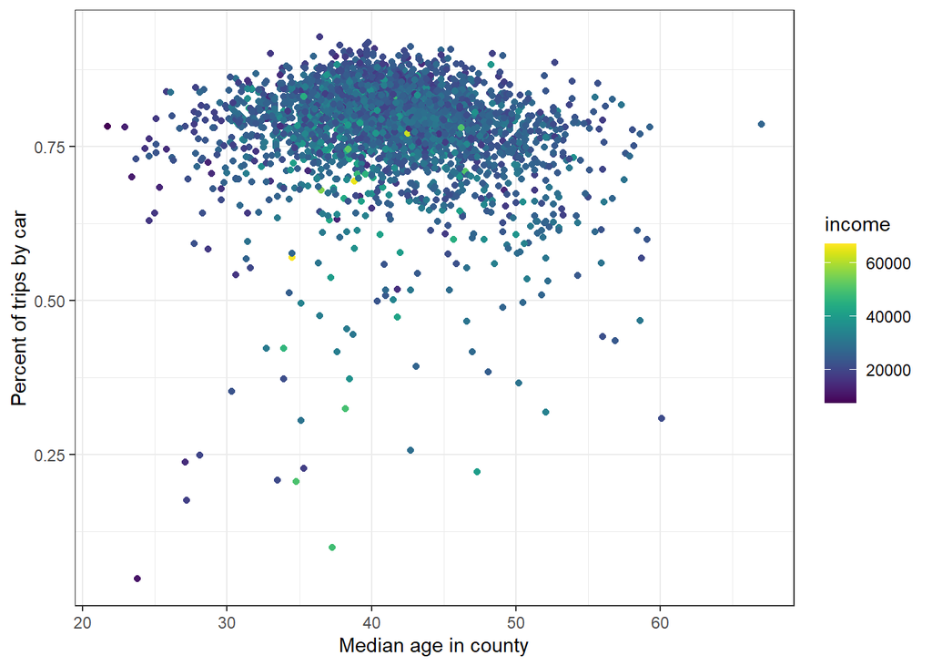

```r
# palettes can be used similarly to what we did before

library(viridis)

pl <- ggplot(plot_data,
       aes(x = age,
           y = pct_by_car,
           color = income)) +
  geom_point() +
  scale_x_continuous(name = "Median age in county") +
  scale_y_continuous(name = "Percent of trips by car") +
  scale_color_viridis() +
  theme_bw()

pl
```

### 3.2. “Area” plots

By area plots we consider plots that have an area within a boundary that can be colored. Parameter fill is used to color that area.

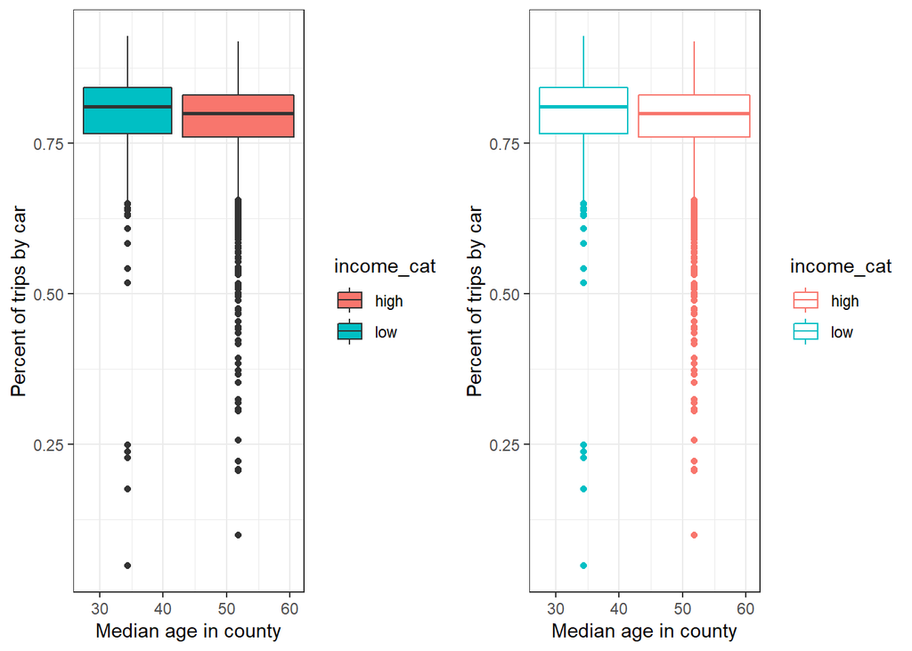

```r
# fill controls the color of the fill while color controls the color of the boundary

p1 <- ggplot(plot_data,
         aes(x = age,
             y = pct_by_car,
         fill = income_cat)) +
    geom_boxplot() +
    scale_x_continuous(name = "Median age in county") +
    scale_y_continuous(name = "Percent of trips by car") +
    theme_bw()

p2 <- ggplot(plot_data,
       aes(x = age,
           y = pct_by_car,
       color = income_cat)) +
  geom_boxplot() +
  scale_x_continuous(name = "Median age in county") +
  scale_y_continuous(name = "Percent of trips by car") +
  theme_bw()

grid.arrange(p1, p2, ncol=2)
```

To manipulate the color of the fill, you can use all the same tricks shown in the scatter plots, only instead of scale_color_ use scale_fill_.

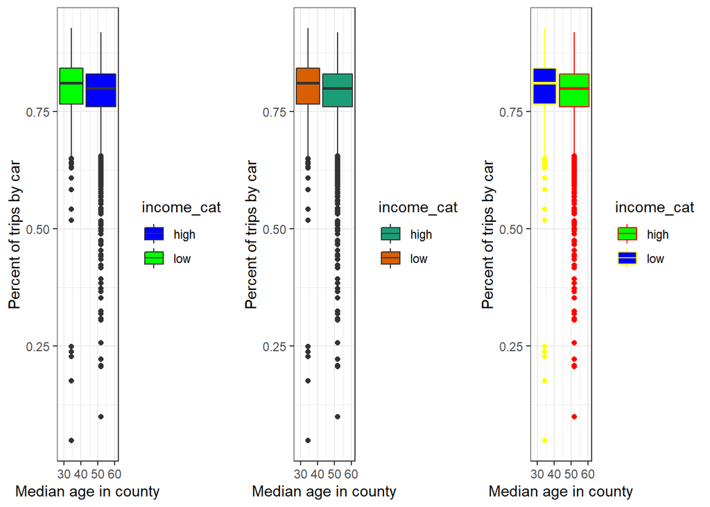

```r
#set the colors manually

p1 <-  ggplot(plot_data,
         aes(x = age,
             y = pct_by_car,
         fill = income_cat)) +
    geom_boxplot() +
    scale_x_continuous(name = "Median age in county") +
    scale_y_continuous(name = "Percent of trips by car") +
    scale_fill_manual(values = c("blue", "green")) +
    theme_bw()

# choose a palette

p2 <- ggplot(plot_data,
         aes(x = age,
             y = pct_by_car,
         fill = income_cat)) +
    geom_boxplot() +
    scale_x_continuous(name = "Median age in county") +
    scale_y_continuous(name = "Percent of trips by car") +
    scale_fill_brewer(palette = "Dark2") +
    theme_bw()

# you can use scale_fill_ and scale_color_ in the same graph. Remember, cale_fill_  controls the fill color, scale_color_ controls boundary color.

p3 <- ggplot(plot_data,
         aes(x = age,
             y = pct_by_car,
         fill = income_cat,
         color = income_cat)) +
    geom_boxplot() +
    scale_x_continuous(name = "Median age in county") +
    scale_y_continuous(name = "Percent of trips by car") +
    scale_fill_manual(values = c("green", "blue")) +
    scale_color_manual(values = c("red", "yellow")) +
    theme_bw()

grid.arrange(p1, p2, p3, ncol=3)
```